# Assignment 9: Neural Nets

## Question 5

Build a neural net model with a hidden layer of size 4, and plot it using the plotnet function from the NeuralNetTools package. Notice how bad this default plotting is. Really, really subpar. Now plot with the fix (originally posted here: https://github.com/fawda123/NeuralNetTools/issues/20).

par(mar = numeric(4)) plotnet(model,pad_x = .5)

What was the difference between the original and the fixed versions?

Answer: The fixed plot is much cleaner and easier to interpret than the original.

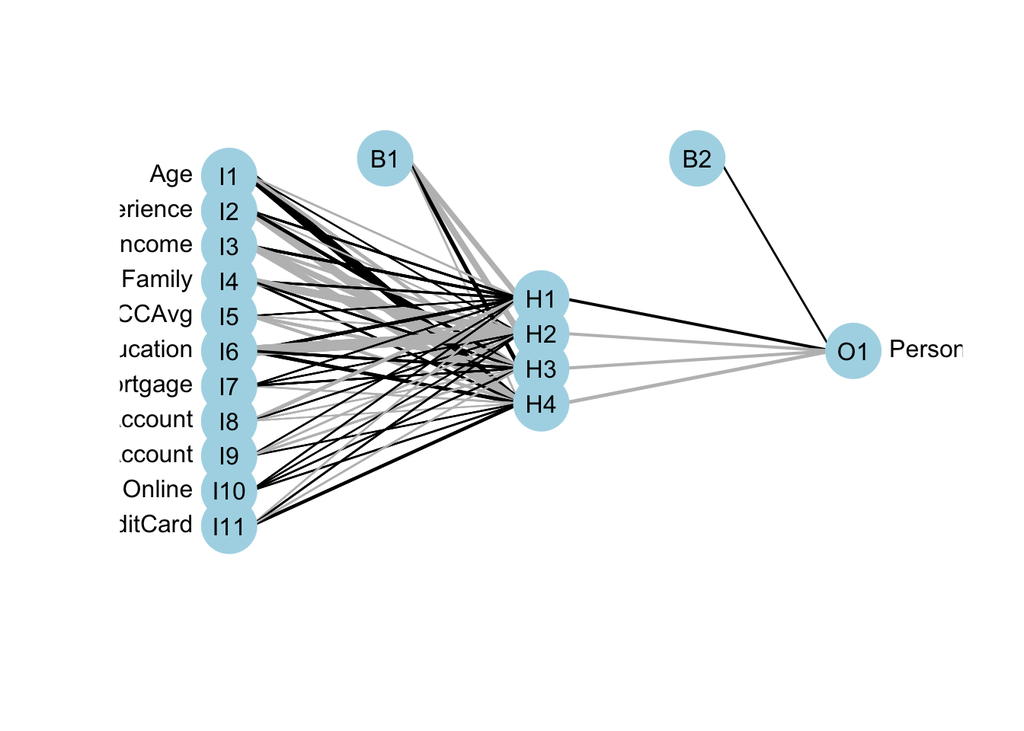

```r
model = nnet(Personal.Loan ~ ., data=train, size = 4)
plotnet(model)
```

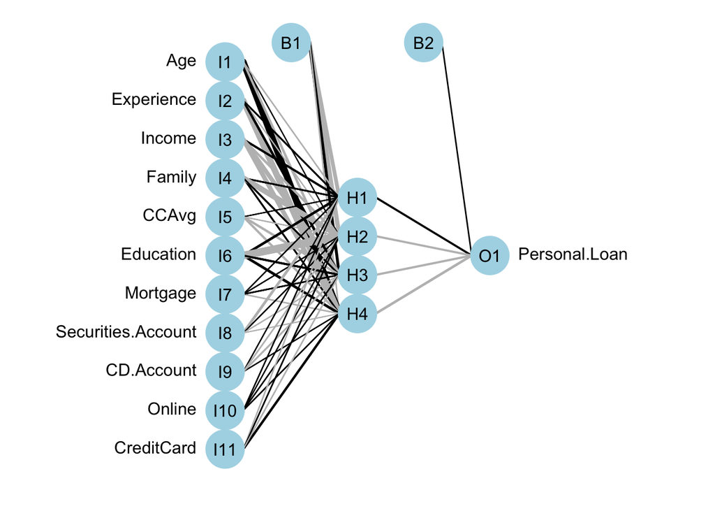

```r
par(mar = numeric(4))
plotnet(model,pad_x = .5)
```

## Question 6

What can we learn about what types of customers accept personal loan offers by visualizing examining the neural net you’ve created? (i.e., what did we say in class from looking at this visual?)

Answer: The neural net provides a visual representation of how different customer characteristics influence the likelihood of accepting a personal loan.

## Question 7

Take a look at your confusion matrix. Also, calculate the error rate and benchmark error rate. How many predictions did you get correct from the model? What is the error rate associated with your model? Is this a useful model?

```r
pred = predict(model, test, type="class")

table(pred,test$Personal.Loan)
```

```
pred    0    1
   0 1346   18
   1   20  116
```

```r
# calculate error rate
error_rate = sum(pred != test$Personal.Loan)/nrow(test)

#calculate benchmark error rate
error_bench = benchmarkErrorRate(train$Personal.Loan, test$Personal.Loan)
```

## Question 8

One could make the argument that we care very much about predicting the True observations correctly in this model. What is sensitivity of this model? Round your answer to two decimal places, e.g., 0.12

Also, how does this rate - essentially an accuracy rate - compare with the error rate you obtained previously? What is the issue with this if predicting True’s accurately was really important to you in this context?

Answer: Sensitivity: 0.87 Sensitivity is much higher than the error rate, which reflects the overall performance. Issue: The model may not adequately prioritize predicting True customers, which could limit its effectiveness in identifying customers likely to accept the loan.

## Question 9

What happens if you don’t standardize? Turn off standardization and re-run your neural network(i.e., Just use hashtags to comment out a couple lines in your code and re-run everything). You will likely get an error if you try to compute the error rate, so just look at the misclassification table instead. What do you see? What you do think happened here?

After you answer this question, just make sure to un-comment your lines of code before knitting.

Answer: The model predicts that everyone will decline the loan (0), and it fails to predict any customers who accept the loan (1). Without standardizing, features with large numbers overshadow smaller features, which confuses the model, so it only predicts the majority class (0) and ignores the rest.